# 0419exam

# 3. Linechart

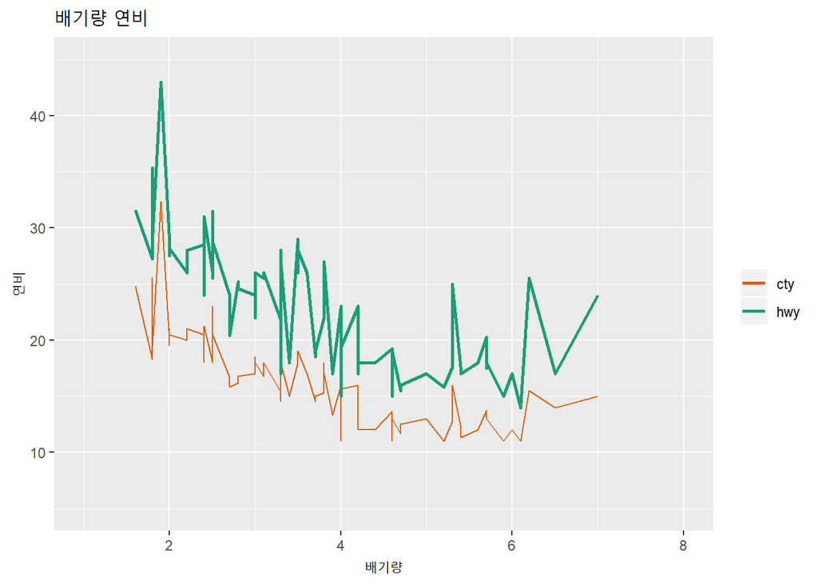

```r
library(dplyr)
d2 = mpg %>% group_by(manu, displ) %>%
    summarise(m1 = mean(cty), m2 = mean(hwy))
ggplot(d2, aes(x=displ)) +
  geom_line(aes(y=m1, color='cty')) +
  geom_line(aes(y=m2, color='hwy'), size=1) +
  scale_colour_manual("", breaks = c("cty", "hwy"),
                          values = c("#d95f02", "#1b9e77")) +
  xlab("배기량") +
  xlim(1, 8) +
  scale_y_continuous("연비", limits = c(5, 45)) +
  labs(title = '배기량 연비')
```

위의 그래프는 배기량에 따른 연비를 꺽은선 그래프로 표시한 것이다. 자료는 mpg 데이터를 이용했고 범례의 hwy는 고속도로 연비, cty는 시내연비이다. 여기서의 그래프의 원리는 ggplot 배경에 각 각의 geom_line 레이어를 더한 것이다. 레이어를 더해서 그래프를 출력한다느 원리를 이해하면 filter 와 select의 기능을 통해 효율적인 데이터의 시각화가 가능해진다.

# 4. Point plot

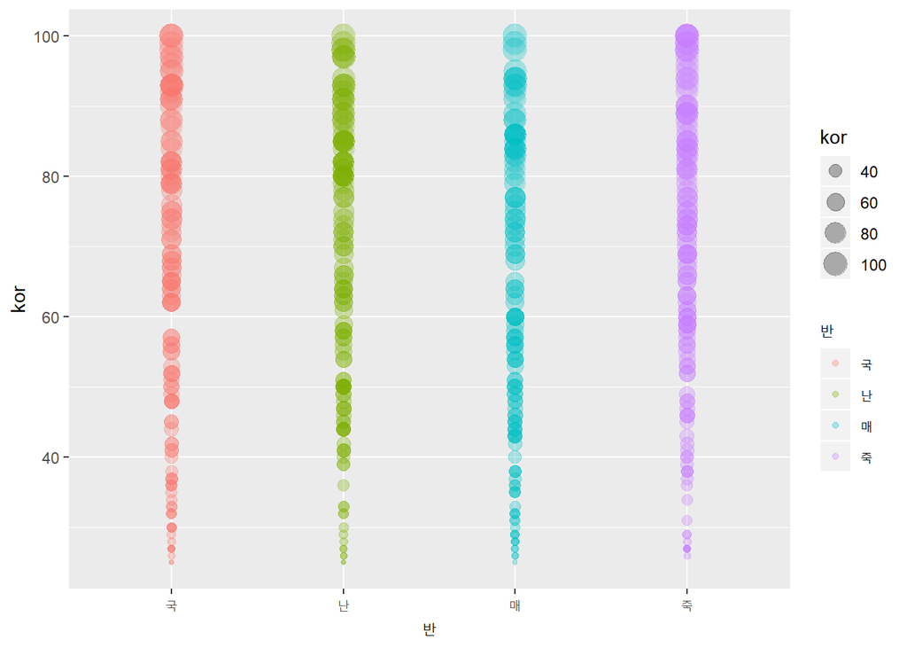

```r
load('data/grade.rda')
ggplot(data, aes(반, kor)) +
    geom_point(aes(color=반, size=kor),
               alpha=0.3)
```

위의 그래프는 반별 국어성적의 분포를 나타낸 것으로 점의 크기는 국어과목 점수를 나타내고 색깔은 반을 나타내어 준다.

# 5. Density plot

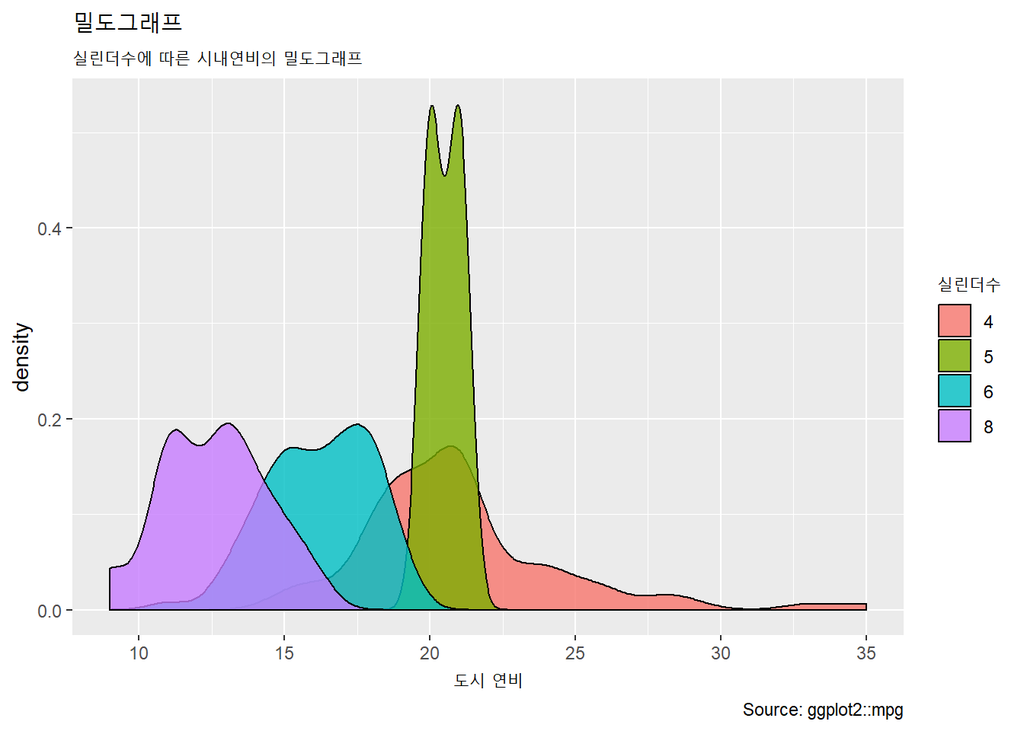

```r
ggplot(mpg, aes(cty)) +
  geom_density(aes(fill=factor(cyl)), alpha=0.8) +
  labs(title="밀도그래프", subtitle = "실린더수에 따른 시내연비의 밀도그래프",
       caption="Source: ggplot2::mpg",
       x = "도시 연비",
       fill = "실린더수")
```

위의 그래프는 실린더 수에 따른 시내연비의 밀도를 나타낸 것이다. 색깔은 실린더 수를 나타내고 x축은 시내연비 y축은 데이터상에 그것의 밀도를 나타내어 주고 있다.

# 6. Violin plot

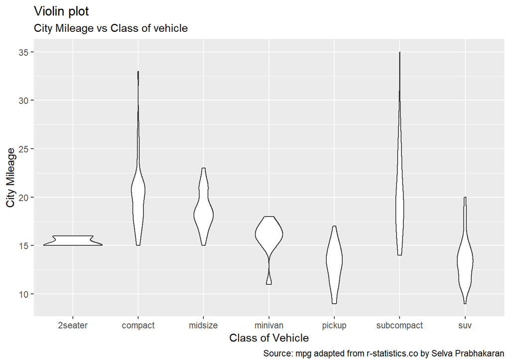

```r
ggplot(mpg, aes(class, cty)) +
geom_violin() +
  labs(title="Violin plot",
       subtitle="City Mileage vs Class of vehicle",
       caption="Source: mpg adapted from r-statistics.co by Selva Prabhakaran",
       x="Class of Vehicle",
       y="City Mileage")
```